# Componente ecológico río Piedras

Piloto reproducible: IIB de macroinvertebrados por tramo (Pinilla-Agudelo et al. 2008, 2014)

Fecha de publicación

11 de septiembre de 2026

## Resumen ejecutivo: integración del IIB con el modelo SWAT

**Objetivo.** Asociar el estado ecológico medido en campo (IIB de macroinvertebrados, y a futuro el IIBComp con peces y perifiton) con las variables hidrológicas y de calidad de agua que simula SWAT (caudal, sedimentos, nitrógeno, fósforo) por subcuenca — para entender qué presiones modeladas se asocian mejor con los patrones bióticos observados en cada tramo del río Piedras, y dejar esa asociación calculable de forma reproducible cada vez que haya datos nuevos de una u otro lado.

**Estrategia de integración** (detalle completo en Sección 8):

1. **Crosswalk tramo↔︎subcuenca**: cada sitio de muestreo biológico se ubica en una subcuenca SWAT específica (Bajo = Los Naranjos = subcuenca 4; Medio = La Lisa = subcuenca 8; Alto = Bocatoma + Finca Atinkana = subcuenca 9).
2. **Alineación temporal**: se usa únicamente la ventana en que ambos conjuntos de datos son comparables — la campaña de muestreo biológico 1 (nov-dic 2024), la única completa en los tres tramos.
3. **Agregación de SWAT a esa misma ventana**: caudal promediado (es una tasa), sedimentos y nutrientes sumados (son cargas acumulables mes a mes).
4. **Normalización por área de drenaje**: las tres subcuencas tienen tamaños distintos, así que los totales crudos no son comparables entre sí sin dividir por km².
5. **Cruce (join)** del IIB por tramo contra esas variables hidrológicas normalizadas, dejando el patrón de unión listo para repetirse con el IIBComp completo más adelante.

**Qué se encontró.** Con el método de puntaje absoluto (Tabla 23-24, Pinilla et al. 2008), el IIB de macroinvertebrados resultó **Alto** en los tres tramos (Bajo 0.67, Medio 0.64, Alto 0.75) — ninguno cae en las categorías Baja o Moderada. Dentro de ese resultado, La Lisa (Medio, subcuenca 8) es el tramo con el IIB relativamente más bajo de los tres, y es también, por un margen amplio, el que exporta más sedimento por km² de drenaje según SWAT — consistente en dirección con lo que ya señalaba el informe de resultados SWAT sobre esa subcuenca como fuente crítica de sedimento. En cambio, nitrógeno y fósforo por área salen casi planos entre los tres tramos, lo que no calza con la narrativa del escenario base 2020 (que ubicaba a las subcuencas bajas como las mayores exportadoras de N/P) — probablemente porque esa comparación es anual y a nivel de toda la cuenca, mientras que este cruce es un corte de solo dos meses entre tres subcuencas. Con n=3 tramos esto es una observación descriptiva, no una correlación con respaldo estadístico. Aparte de la integración con SWAT, el proceso también destapó dos problemas de calidad de dato en el Excel de Fanny: la fila “BMWP” de la hoja `IIBMA` no coincide con el BMWP/Col recalculado aquí, y el lookup de tolerancia (VT) cubre mal el tramo Bajo por la ausencia de *Atya* en la tabla de referencia 2008.

**Qué queda pendiente** (detalle completo en Sección 9): tabular y calcular el IIB de **peces** (falta el puntaje 0-1, aunque la tabla 2008 ya está completa) y de **perifiton** (faltan las métricas de gremios ecológicos); incorporar **vegetación de ribera** cuando se retome; completar la **segunda campaña** (mayo 2025) en cuanto se vuelva a muestrear Los Naranjos, para poder comparar por periodo (lluvia/sequía) como plantea Pinilla et al. (2014) en lugar de un único valor “actual”; ampliar el **lookup de tolerancia (VT)** con literatura neotropical; y, ya del lado de esta integración, repetir el cruce con SWAT usando el **IIBComp** completo en vez de solo `iib_macroinv`, una vez peces y perifiton estén calculados.

## Propósito y alcance de este documento

Este es un **piloto**, no el análisis final: implementa de principio a fin únicamente el componente de **macroinvertebrados acuáticos**, que es el que tiene datos suficientes en `Informe_Fanny.xlsx` para correr todo el flujo. Usa las tablas de puntaje absoluto de la propuesta original (Pinilla- Agudelo, Rodríguez-Sandoval y Camacho-Botero; Convenio UNAL–MAVDT 004/2007, 2008; retomada en Pinilla et al. 2014), en vez de una estandarización relativa entre tramos — ver la sección “Puntaje absoluto” para el porqué del cambio. Sirve para validar la metodología en código antes de invertir tiempo en peces y perifiton (que todavía les faltan pasos, ver auditoría más abajo) y en la vinculación con las subcuencas del SWAT.

Al final del documento (Sección 9) se detalla qué falta para completar los otros componentes y para unir esto con las salidas del modelo hidrológico.

## Datos de entrada

- **Descargar datos crudos para IIB** ([enlace.xlsx](https://javier-2712.github.io/Proyectos/2.proyecto.model.r.piedras/Informe_Fanny.xlsx))
- **Descargar datos ambientales para SWAT** ([enlace.xlsx](https://javier-2712.github.io/Proyectos/2.proyecto.model.r.piedras/rch.xlsx))

Tabla 1: Registros crudos disponibles por tramo y sitio

| tramo | sitio | n_registros |
| --- | --- | --- |
| Bajo | Los Naranjos | 95 |
| Medio | La Lisa | 172 |
| Alto | Bocatoma | 305 |
| Alto | Finca Atinkana | 50 |

### Dos campañas de muestreo: por qué el pipeline usa solo la primera

**Importante**

La hoja `Macroinv.` tiene datos de **dos campañas**: nov-dic 2024 (los 3 tramos) y mayo 2025 (solo Alto y Medio; Bajo no se volvió a muestrear). Sumarlas sin distinguir infla la abundancia y la riqueza — un primer intento de este pipeline lo hizo por error y los resultados no coincidían con la tabulación de Fanny. Filtrando solo la campaña 1 (nov-dic 2024) los números sí calzan exactamente con su hoja `IIBMA` (Alto: 978 ind./31 familias, Bajo: 556/27, Medio: 768/29).

Esto además es lo metodológicamente correcto: Pinilla et al. (2014) calculan el IIB **por periodo** (lluvia y sequía por separado), no mezclado. De aquí en adelante el documento trabaja solo con la campaña 1, que es la única completa en los 3 tramos.

Tabla 2: Datos disponibles de la 2ª campaña (mayo 2025) — vista previa, aún sin Bajo

| tramo | sitio | fecha | n_registros |
| --- | --- | --- | --- |
| Medio | La Lisa | 2025-05-03 | 39 |
| Alto | Bocatoma | 2025-05-02 | 175 |
| Alto | Finca Atinkana | 2025-05-03 | 50 |

La correspondencia tramo-sitio-subcuenca SWAT usada en todo el documento es la que efectivamente se usó para tabular estos datos (confirmada cruzando las hojas `Macroinv.`, `Peces`, `Perifiton` y `Chl-a`):

| Tramo | Sitio(s) | Subcuenca SWAT |
| --- | --- | --- |
| Bajo | Los Naranjos | 4 |
| Medio | La Lisa | 8 |
| Alto | Bocatoma + Finca Atinkana | 9 |

## Tabulación por tramo

Tabla 3: Cinco familias más abundantes por tramo

| tramo | orden | familia | abundancia |
| --- | --- | --- | --- |
| Bajo | Decapoda | Atyidae | 268 |
| Bajo | Ephemeroptera | Baetidae | 84 |
| Bajo | Ephemeroptera | Leptohyphidae | 46 |
| Bajo | Coleoptera | Elmidae | 28 |
| Bajo | Plecoptera | Perlidae | 26 |
| Medio | Diptera | Chironomidae | 209 |
| Medio | Ephemeroptera | Baetidae | 136 |
| Medio | Coleoptera | Elmidae | 127 |
| Medio | Diptera | Simuliidae | 43 |
| Medio | Ephemeroptera | Leptohyphidae | 40 |
| Medio | Hemiptera | Veliidae | 40 |
| Alto | Diptera | Chironomidae | 223 |
| Alto | Trichoptera | Leptoceridae | 167 |
| Alto | Ephemeroptera | Baetidae | 153 |
| Alto | Coleoptera | Elmidae | 102 |
| Alto | Hemiptera | Naucoridae | 94 |

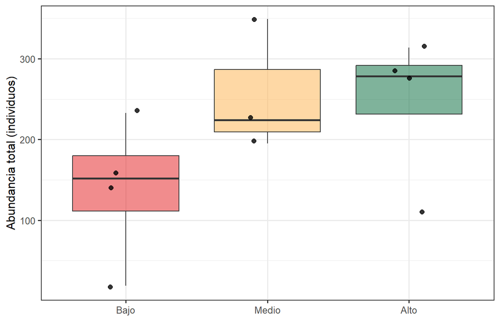

Abundancia total por réplica dentro de cada tramo. Cada punto es una réplica de muestreo, no solo el promedio del tramo.

## Métricas por tramo

Tabla 4: Métricas de macroinvertebrados por tramo (Tabla 23, Pinilla et al. 2008)

| Métrica | Bajo | Medio | Alto |
| --- | --- | --- | --- |
| Taxones totales (TT) | 27.0 | 29.0 | 31.0 |
| Taxones Trichoptera (T) | 4.0 | 5.0 | 5.0 |
| Taxones Diptera (D) | 5.0 | 3.0 | 8.0 |
| % Ephemeroptera (E) | 24.5 | 24.0 | 22.0 |
| % EPT | 32.7 | 32.8 | 47.4 |
| % Oligoquetos (O) | 0.0 | 0.0 | 0.7 |
| Taxones intolerantes (I) | 7.0 | 11.0 | 14.0 |
| % Taxones tolerantes (Tol) | 45.7 | 60.4 | 44.6 |
| % Recolectores (R) | 82.9 | 50.4 | 62.0 |
| Taxones filtradores (F) | 1.0 | 2.0 | 2.0 |
| Índice de Hilsenhoff (IH) | 4.6 | 5.5 | 5.1 |
| Abundancia total (individuos) | 556.0 | 768.0 | 978.0 |
| Cobertura del lookup VT (%) | 20.9 | 66.0 | 62.9 |
| BMWP/Col | 154.0 | 175.0 | 183.0 |

**NotaChequeo de calidad frente al Excel de Fanny**

El BMWP/Col calculado aquí (presencia/ausencia de familias × puntaje BMWP/Col, sumado por tramo) **no coincide** con la fila “BMWP” de la hoja `IIBMA` del Excel (que mostraba 978 / 556 / 768, exactamente los mismos valores que la fila de abundancia total). Todo indica que esa fila se copió mal desde la tabla de arriba. Vale la pena confirmarlo con Fanny y usar el valor recalculado aquí (154 / 175 / 183 para Bajo/Medio/Alto).

Además, 7 familias presentes en los datos no tienen puntaje BMWP/Col asignado en la tabla de Fanny (`Atyidae`, `Limoniidae`, `Crambidae`, `Lumbriculidae`, `Perlidae`, `Leptoceridae`, `Limnesiidae`) — quedan excluidas del cálculo actual. Conviene completarlas con la tabla oficial de Roldán (2003) antes de dar el BMWP por definitivo.

**AdvertenciaCobertura del lookup de tolerancia (VT) — leer antes de interpretar I, Tol e IH**

Las métricas `I`, `Tol` e `IH` necesitan un valor de tolerancia (VT) por género, tomado de la Tabla 22 de la propuesta 2008. Esa tabla se construyó con estudios de Norteamérica, Europa y Australia, así que **no cubre todos los géneros neotropicales** presentes en el río Piedras. La cobertura real por tramo es 21% / 66% / 63% (Bajo/Medio/Alto) — el tramo Bajo es el más débil, porque ahí domina *Atya* (Atyidae, camarones), un género que la Tabla 22 no incluye en absoluto. `I`, `Tol` e `IH` en el tramo Bajo deben leerse con esa reserva. El lookup completo está en `data/lookup/vt_macroinvertebrados.csv`, con una columna `fuente_vt` que indica si el valor es del género exacto, de un género o familia cercana usada como aproximación, o si no hay dato.

## Puntaje absoluto (Tabla 23, Pinilla et al. 2008)

Esto reemplaza la estandarización relativa (min-max entre tramos) de la versión anterior de este documento. En una conversación con Fanny sobre por qué no lograba replicar la estandarización del método, encontramos el informe técnico original (Convenio UNAL–MAVDT 004/2007, 2008) del que sale la propuesta de Pinilla: ahí están las tablas de puntaje completas, y el propio documento aclara que **no se derivaron estadísticamente de datos de campo** — son adaptadas de estudios de otras regiones del mundo, como punto de partida a priori:

> *“Los umbrales propuestos a priori deberán confirmarse o modificarse con base en datos de campo.”* (2008, repetido para cada comunidad)

Por eso no había ninguna estandarización “oculta” que replicar. Con las tablas ya en mano, usarlas directamente es más defendible que la estandarización relativa: cada métrica recibe 0,2 / 0,6 / 1 según en qué franja cae su valor crudo, sin depender de cuántos tramos se muestrearon.

Tabla 5: Puntaje absoluto (0,2 / 0,6 / 1) por métrica y tramo — Tabla 23

[output not shown]

## IIB de macroinvertebrados por tramo

`IIBMacroin = (TT + T + D + E + EPT + O + I + Tol + R + F + IH) / 11`, clasificado según la Tabla 24 de la propuesta 2008 (0-0,3 baja · 0,31-0,6 moderada · 0,61-1 alta — la misma escala que usan las Tablas 19 y 29 para perifiton y peces, así que sirve igual para los tres).

Tabla 6: IIB de macroinvertebrados por tramo

| Tramo | IIB Macroinvertebrados | Clase |
| --- | --- | --- |
| Bajo | 0.67 | Alta |
| Medio | 0.64 | Alta |
| Alto | 0.75 | Alta |

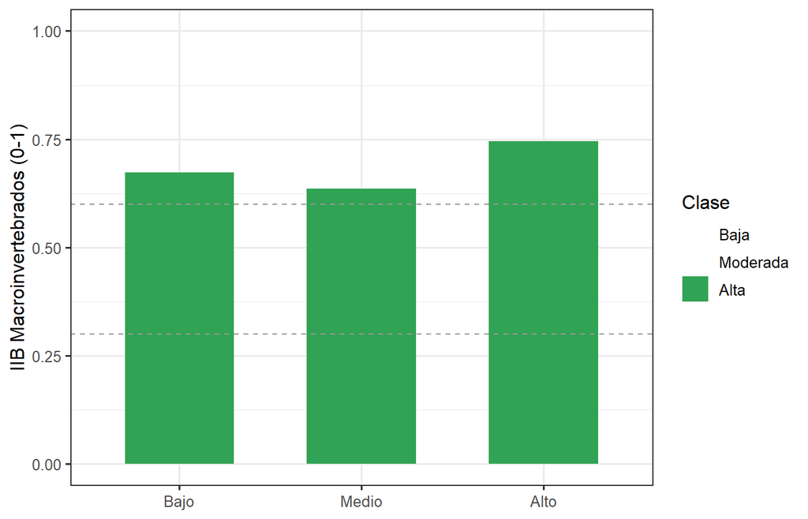

IIB de macroinvertebrados por tramo (Tabla 23-24, Pinilla et al. 2008).

## Integración con SWAT

Primer cruce entre el componente biológico y el modelo hidrológico SWAT, correspondiente al paso 7 de Sección 9. Usa exclusivamente la campaña 1 (nov-dic 2024), la única con datos completos de macroinvertebrados en los tres tramos — la misma razón por la que el resto de este documento excluye mayo 2025.

Tabla 7: Salidas SWAT agregadas por subcuenca, nov-dic 2024 (subcuencas 4, 8 y 9)

| Sub | Área (km²) | Q (cms) | Sed (t) | Sed (t/km²) | N (kg) | N (kg/km²) | P (kg) | P (kg/km²) |
| --- | --- | --- | --- | --- | --- | --- | --- | --- |
| 4 | 15.2 | 0.8 | 15506.0 | 1016.8 | 1904.6 | 124.9 | 410.1 | 26.9 |
| 8 | 13.7 | 0.6 | 69470.0 | 5059.7 | 1425.4 | 103.8 | 346.9 | 25.3 |
| 9 | 33.8 | 1.4 | 722.7 | 21.4 | 3553.0 | 105.2 | 903.9 | 26.8 |

El caudal se promedia entre los dos meses (es una tasa, no un acumulado); sedimentos y nutrientes se suman (son cargas mensuales, sí acumulables). `sedimento_ton_km2`, `n_total_kg_km2` y `p_total_kg_km2` normalizan por área de drenaje, que varía bastante entre las tres subcuencas (Tabla 7) y por eso los totales crudos no son directamente comparables entre tramos. La tabla impresa omite el desglose intermedio (`n_organico_kg`, `p_organico_kg`, `no3_kg`, `nh4_kg`) por espacio — sigue disponible en `swat_agg` y en el CSV exportado más abajo.

El crosswalk tramo-subcuenca es el mismo de la sección de datos de entrada, ahora como objeto de R para poder unirlo:

Tabla 8: Cruce IIB de macroinvertebrados (puntaje absoluto, Tabla 23-24) x variables SWAT por tramo (nov-dic 2024)

| Tramo | Sitio | IIB | Clase | TT | EPT (%) | Abund. | Sed (t/km²) | N (kg/km²) | P (kg/km²) |
| --- | --- | --- | --- | --- | --- | --- | --- | --- | --- |
| Bajo | Los Naranjos | 0.7 | Alta | 27 | 32.7 | 556 | 1016.8 | 124.9 | 26.9 |
| Medio | La Lisa | 0.6 | Alta | 29 | 32.8 | 768 | 5059.7 | 103.8 | 25.3 |
| Alto | Bocatoma/Atinkana | 0.7 | Alta | 31 | 47.4 | 978 | 21.4 | 105.2 | 26.8 |

La tabla impresa muestra las columnas más interpretables y evita repetir lo que ya está en Tabla 7 (área, caudal, cargas crudas). El objeto `cruce_iib_swat` y el CSV exportado sí conservan las ~20 columnas completas (`SUB`, cargas crudas de N/P, `no3_kg`, `nh4_kg`, etc.) por si se necesitan para un análisis posterior.

`TT` (taxones totales) y `EPT` (% EPT) se traen de `metricas` como referencia rápida de riqueza y sensibilidad — los mismos nombres de columna que usa el resto de este documento desde el cambio a puntaje absoluto.

**ImportanteUn patrón hidrológico que vale la pena discutir con el equipo**

Estas dos observaciones vienen directo de `swat_agg` (Tabla 7) y no dependen del método de puntaje biológico, así que siguen siendo válidas pese al cambio de metodología del IIB:

**Sedimentos**: normalizando por área de drenaje, La Lisa (Medio, sub. 8) exporta muchísimo más sedimento por km² que los otros dos tramos — consistente con lo ya identificado en el informe de resultados SWAT sobre esa subcuenca como fuente crítica.

**Nitrógeno y fósforo**: una vez normalizados por área, son prácticamente planos entre los tres tramos. Esto no calza directamente con la narrativa del escenario base 2020 (que señala a las subcuencas bajas como las mayores exportadoras de N/P orgánico) — probablemente porque esa comparación es anual y a nivel de las 10 subcuencas, mientras que este cruce es un corte de solo 2 meses entre 3 subcuencas. Confirmar con Carlos antes de sacar conclusiones.

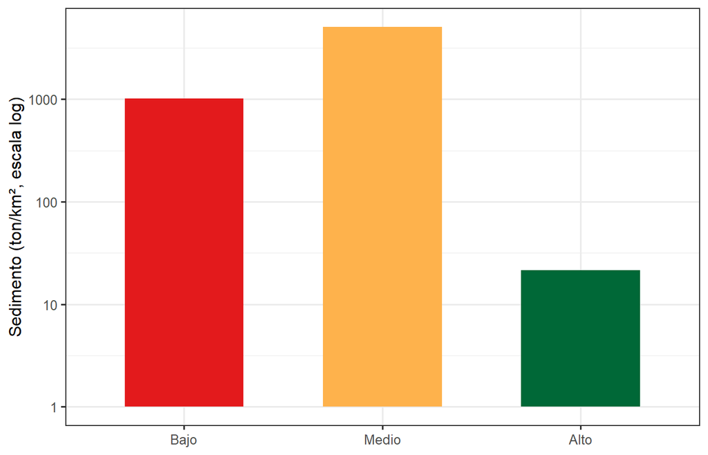

Sedimento exportado por área de drenaje, por tramo (escala log).

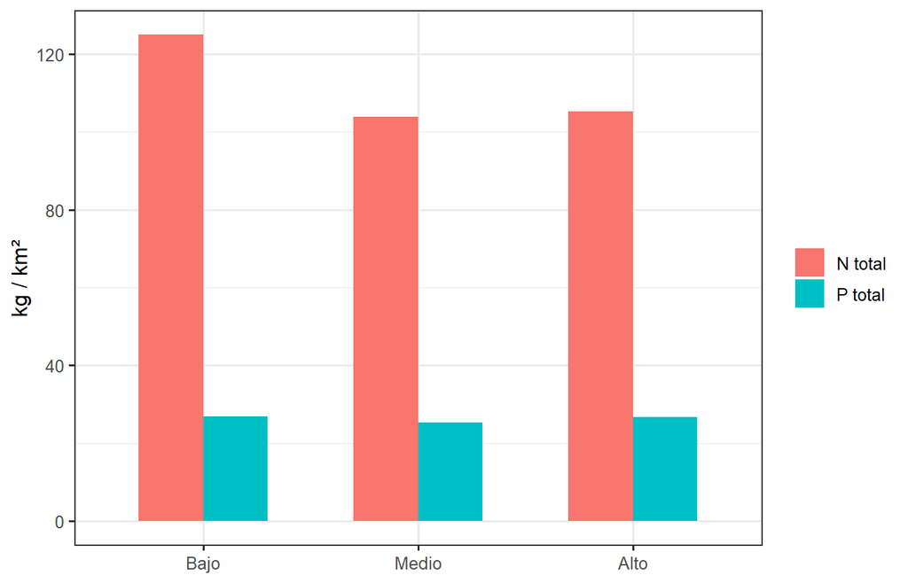

Nitrógeno y fósforo total por área de drenaje, por tramo.

Las tres figuras anteriores muestran cada variable por separado; la siguiente las junta para ver el patrón de una vez: IIB de macroinvertebrados contra presión de sedimento, por tramo.

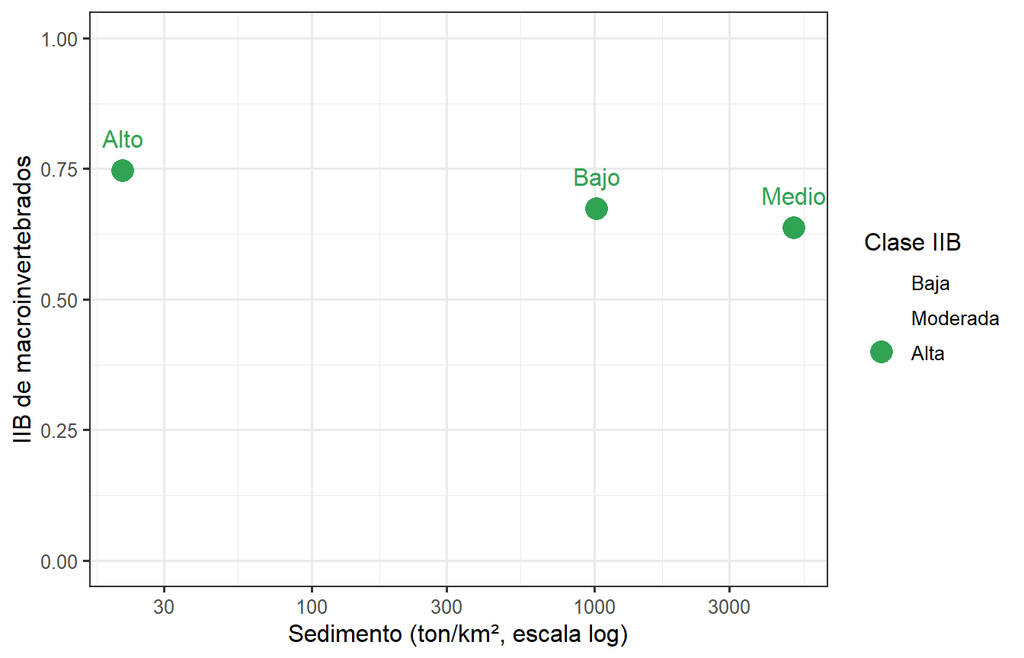

Síntesis: IIB de macroinvertebrados vs. sedimento exportado por área de drenaje, por tramo (nov-dic 2024). El eje de sedimento está en escala log por la magnitud de la diferencia entre tramos.

La Lisa (Medio) queda en la esquina menos favorable de los dos ejes a la vez (más sedimento, menor IIB relativo), y Bocatoma/Atinkana (Alto) en la opuesta — el mismo patrón que ya se describió en texto, pero de un vistazo. Sigue siendo n=3, así que esto es una observación para ilustrar, no una correlación estadística; vale como punto de partida para la conversación con el equipo sobre qué tan sólido se ve una vez estén peces y perifiton.

Este cruce usa `iib_macroinv` porque es el único componente calculado hasta ahora (Sección 9). En cuanto peces y perifiton estén completos, el mismo patrón de unión (`crosswalk_swat` + `left_join`) sirve para cruzar el `IIBComp` completo contra estas mismas variables SWAT.

## Próximos pasos

Este piloto muestra el flujo completo para **un** componente, ya con el método de puntaje absoluto de la propuesta 2008. Lo que falta para tener el `IIBComp` real del río Piedras:

1. **Peces**: la propuesta 2008 trae la tabla de puntaje absoluto completa (Tabla 28: %individuos nativos, %especies nativas, cambio en %migratorios, cambio en %especies amenazadas —usa el Libro Rojo de peces dulceacuícolas de Colombia—, %reducción de tallas, %carnívoros micrófagos, %carnívoros macrófagos, %individuos con anormalidades). `puntaje_tabla()` ya sirve para esto — solo falta tabular esas 8 métricas a partir de la hoja `Peces` del Excel de Fanny y aplicar la misma función. El propio documento 2008 advierte que los IIB de peces son “muy inconsistentes de una región a otra” por variables macroescalares (tamaño de cuenca, biogeografía) — es una limitación reconocida del método, no un error de cálculo.
2. **Perifiton**: la Tabla 18 (2008) también está completa (10 métricas basadas en diatomeas: proporción de no-diatomeas, %sensitivas, %tolerantes, eutráficas, acidobiónticas, alcalifílicas, %móviles, %polisapróbicas, %exigentes en oxígeno, clorofila-a), con puntaje 0 / 0,3 / 0,7 / 1 (cuatro franjas, no tres como macroinvertebrados y peces — `puntaje_tabla()` habría que extenderla a un caso de 3 cortes interiores). Falta tabular las métricas de gremios ecológicos en el Excel antes de poder aplicarla.
3. **Vegetación de ribera**: excluida por ahora, según lo acordado. La Tabla 9/11 (Pinilla et al. 2014, retomando UNC y MAVDT 2008) también tiene su propio puntaje absoluto listo para cuando se retome.
4. **Segunda campaña (mayo 2025)**: ya hay datos de Alto y Medio para un segundo periodo. En cuanto se muestree Bajo en esa misma ventana, se puede calcular el IIB por periodo (p.ej. lluvia vs. sequía) tal como lo plantea Pinilla et al. (2014), en lugar de un único valor “actual”.
5. Una vez estén los tres, replicar exactamente este mismo patrón (`puntaje_tabla()` + `clasificar_iib()` ya sirven para cualquiera de los tres) y calcular: `IIBComp = (IIBMacroinv·0.25 + IIBPeces·0.25 + IIBPerif·0.25 + IIBVegRib·0.25)` (ajustando los pesos si se decide no usar 0.25 parejo, p.ej. mientras no haya vegetación de ribera).
6. **Completar el lookup de tolerancia (VT)**: el de macroinvertebrados (`data/lookup/vt_macroinvertebrados.csv`) solo cubre géneros que aparecen en la Tabla 22 del documento 2008 (Norteamérica/Europa/ Australia) — varios géneros neotropicales del río Piedras quedaron sin VT (marcados en la columna `fuente_vt`). Completar esto con literatura regional (p.ej. Tomanova et al. 2006, en Sudamérica) mejoraría especialmente el tramo Bajo.
7. **Integración con SWAT (parcial)**: ya hecha para `iib_macroinv` en Sección 8, restringida a nov-dic 2024 (única campaña completa en los tres tramos). Falta repetir el cruce con `iib_comp` una vez estén peces y perifiton, y decidir qué hacer con mayo 2025 cuando Los Naranjos se vuelva a muestrear en esa ventana.